# Scientific Programming Project

Thales A. de M. Fernandes

2022-08-15

## 1. Introduction

The detailed comparison of homologous protein structures can be used to infer pathways for evolutionary process, mechanisms for conformational changes, dynamics, internal motions and intrinsic dynamics, structure rearrangements, and conformational and allosteric mechanisms. The increasing availability of high-resolution protein structures allows the integration of molecular structure, dynamics and evolution analysis.

In this context, this project aimed to process, organize and explore structure and sequence data using `bio3d` package Grant et al. (2006) Skjærven et al. (2014) Grant, Skjærven, and Yao (2021). The goals of this project are read and write structures, perform atom summaries, atom selection, re-orientation, superposition, clustering, distance matrix analysis, structure and sequence conservation analysis, and principal component analysis (PCA) from Protein Data Bank (PDB) database Berman et al. (2000).

## 2. Exploratory data analysis of protein structure and sequence

The (PBD) is a database of protein structures grouped in .PDB files, which contains a list of all atoms, the x, y, z coordinates and secondary structure elements.

```r
#Read a PDB file
pdb <- read.pdb("4q21")
```

```
##   Note: Accessing on-line PDB file
```

```r
print(pdb)
```

```
##
##  Call:  read.pdb(file = "4q21")
##
##    Total Models#: 1
##      Total Atoms#: 1447,  XYZs#: 4341  Chains#: 1  (values: A)
##
##      Protein Atoms#: 1340  (residues/Calpha atoms#: 168)
##      Nucleic acid Atoms#: 0  (residues/phosphate atoms#: 0)
##
##      Non-protein/nucleic Atoms#: 107  (residues: 80)
##      Non-protein/nucleic resid values: [ GDP (1), HOH (78), MG (1) ]
##
##    Protein sequence:
##       MTEYKLVVVGAGGVGKSALTIQLIQNHFVDEYDPTIEDSYRKQVVIDGETCLLDILDTAG
##       QEEYSAMRDQYMRTGEGFLCVFAINNTKSFEDIHQYREQIKRVKDSDDVPMVLVGNKCDL
##       AARTVESRQAQDLARSYGIPYIETSAKTRQGVEDAFYTLVREIRQHKL
##
## + attr: atom, xyz, seqres, helix, sheet,
##         calpha, remark, call
```

```r
attributes(pdb)
```

```
## $names
## [1] "atom"   "xyz"    "seqres" "helix"  "sheet"  "calpha" "remark" "call"
##
## $class
## [1] "pdb" "sse"
```

```r
head(pdb$atom)
```

```
##   type eleno elety  alt resid chain resno insert      x      y      z o     b
## 1 ATOM     1     N <NA>   MET     A     1   <NA> 64.080 50.529 32.509 1 28.66
## 2 ATOM     2    CA <NA>   MET     A     1   <NA> 64.044 51.615 33.423 1 29.19
## 3 ATOM     3     C <NA>   MET     A     1   <NA> 63.722 52.849 32.671 1 30.27
## 4 ATOM     4     O <NA>   MET     A     1   <NA> 64.359 53.119 31.662 1 34.93
## 5 ATOM     5    CB <NA>   MET     A     1   <NA> 65.373 51.805 34.158 1 28.49
## 6 ATOM     6    CG <NA>   MET     A     1   <NA> 65.122 52.780 35.269 1 32.18
##   segid elesy charge
## 1  <NA>     N   <NA>
## 2  <NA>     C   <NA>
## 3  <NA>     C   <NA>
## 4  <NA>     O   <NA>
## 5  <NA>     C   <NA>
## 6  <NA>     C   <NA>
```

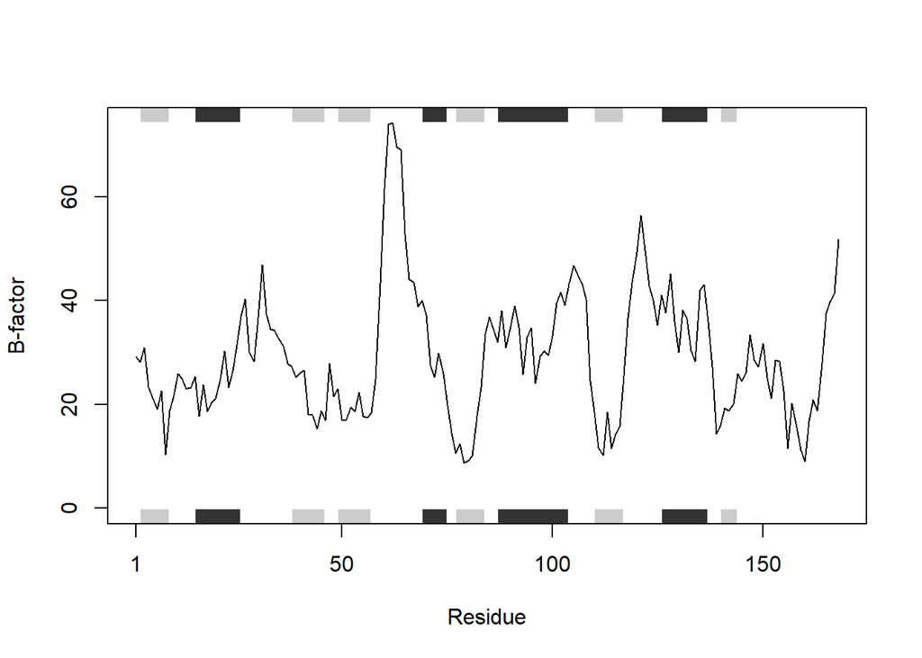

```r
plot.bio3d(pdb$atom$b[pdb$calpha], sse=pdb, typ="l", ylab="B-factor") #Plotting the B-factor
```

```r
#Select and write a PDB object

b.inds <- atom.select(pdb, "back") #selecting the backbone atoms
backpdb <- trim.pdb(pdb, b.inds) #creating a new object of backbone atoms
write.pdb(backpdb, file="~/project/data/processed/4q21_back.pdb") #write a .PDB file

#Identification of dynamic domains
pdb <- read.pdb("1d1d", multi=TRUE) # Read multi-model PDB file
```

```
##   Note: Accessing on-line PDB file
```

```r
gs <- geostas(pdb)
```

```
##   .. 220 'calpha' atoms selected
##   .. 'xyz' coordinate data with 20 frames
##   .. 'fit=TRUE': running function 'core.find'
##   .. coordinates are superimposed to core region
##   .. calculating atomic movement similarity matrix ('amsm.xyz()')
##   .. dimensions of AMSM are 220x220
##   .. clustering AMSM using 'kmeans'
##   .. converting indices to match input 'pdb' object
##      (additional attribute 'atomgrps' generated)
```

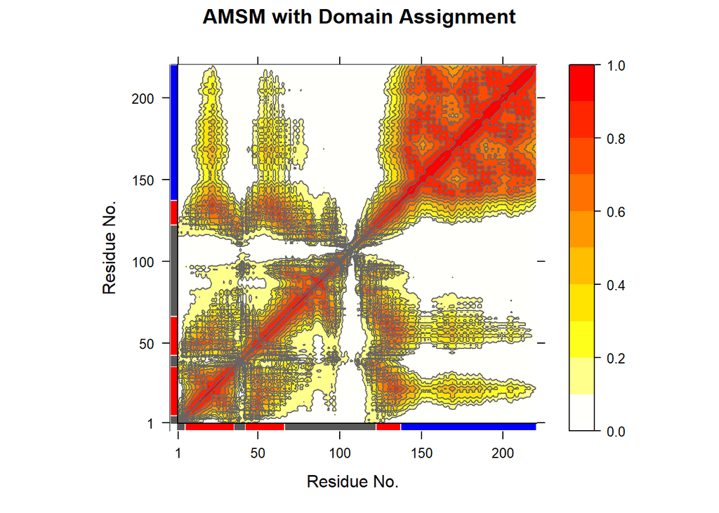

```r
plot(gs)
```

## 3. Comparative analysis of protein structures

### 3.1. Structure search and selection

From the protein sequence or database identifier, related structures can be collected from the PDB database.

In the example below, structures correlated with protein kinase A (PDB: 1L3R) are identified, annotated and downloaded.

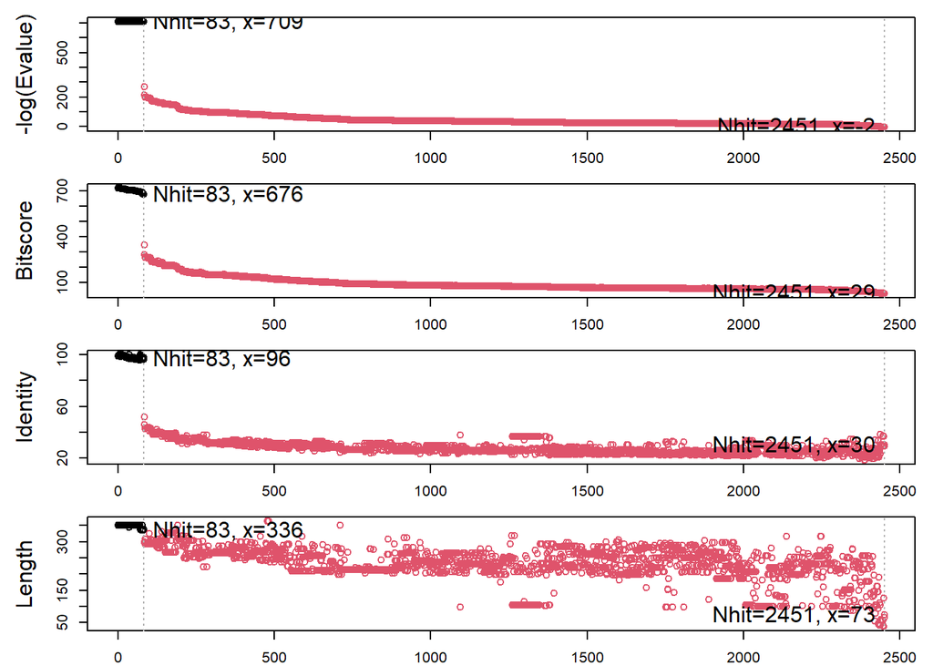

```r
aa <- get.seq("1L3R_E", outfile = "~/project/data/raw/seqs.fasta") #Obtain the protein sequence

blast <- blast.pdb(aa) #find similar sequences using BLAST sequence alignment algorithm

hits <- plot(blast) #Plot the BLAST results
```

```r
annotation <- pdb.annotate(hits) #Annotate the BLAST results into the variable "annotation"

pdb.id <- with(annotation, subset(hits$pdb.id,resolution<=3)) #Filtering structures by resolution < 3

files <- get.pdb(pdb.id, path="~/project/data/raw", split=TRUE) #Download protein structures and split into single chains
```

### 3.2. Multiple Sequence Alignment

In this step, the selected structures are submitted to multiple sequence alignment algorithm using `MSA` package Bodenhofer et al. (2015).

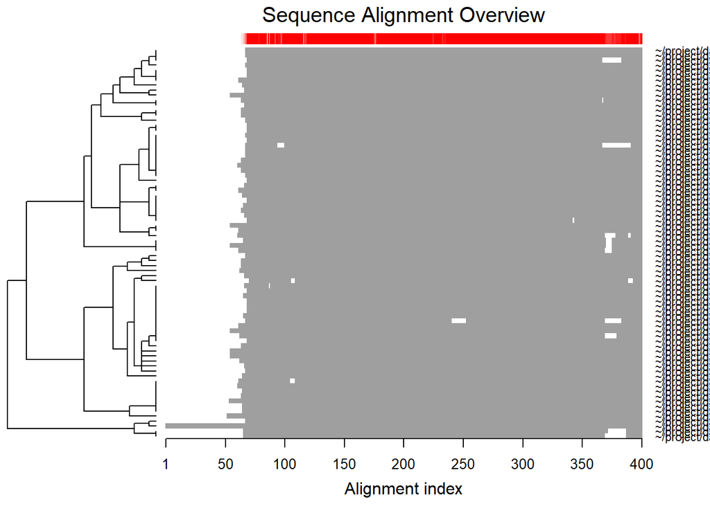

```r
pdbs <- pdbaln(files, exefile = "msa", outfile = "aln.fa") # Align protein structures present in files variable
plot(pdbs)
```

### 3.3. Structure Fitting and analysis

```r
cores <- core.find(pdbs) #Find the core in the aligned structures
xyz <- pdbfit(pdbs, inds=cores) #Obtain the coordinates of the core
```

### 3.4. Principal Component Analysis

In this step, the superimposed structures are compared using principal component analysis (PCA). The PCA correspond to a powerful multivariate statistical technique to reduce the dimensionality of complex data into principal components (PCs). The PCA highlights the patterns and relationships present in protein structures transforming atomic coordinates into PCs that represent directions where the structures displays largest variances.

```r
#Apply PCA for the aligned and non-gaped structures
pc <- pca(xyz, rm.gaps=TRUE)
```

```
## NOTE: Removing 121 gap positions with missing coordinate data
##       retaining 284 non-gap positions for analysis.
```

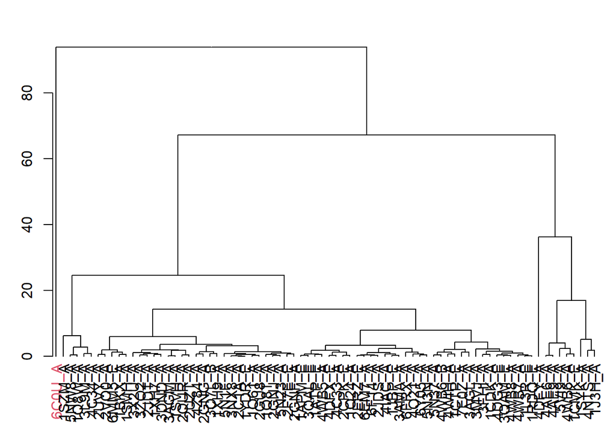

```r
#Structure clustering in the PC1-PC2 plane
d <- dist(pc$z[, 1:2]) #Specifying the PCs
hc <- hclust(d) #Clustering
hclustplot(hc, k=2, labels=pdb.id) #Plotting the clustering
```

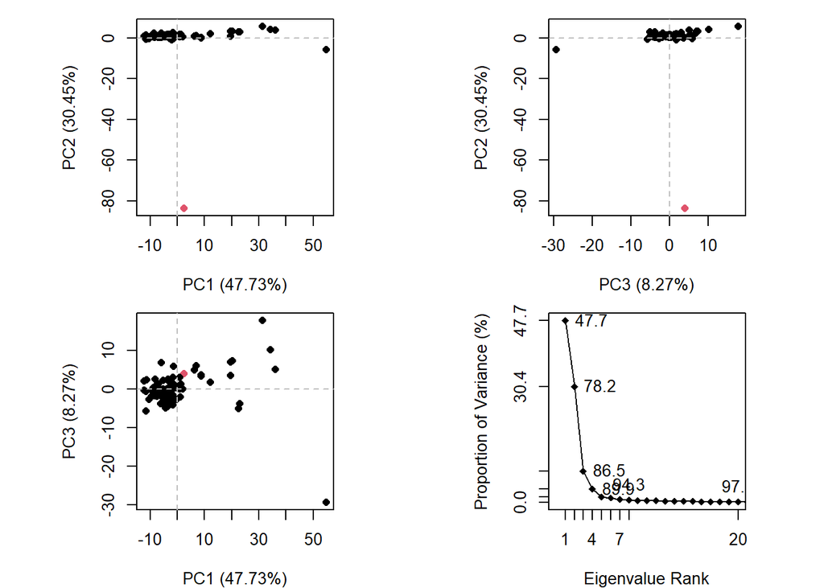

```r
grps <- cutree(hc, k=2)

#Generate conformer plot, scree plot, and residue loadings plot
plot(pc, col=grps) #Plotting the PCA
```

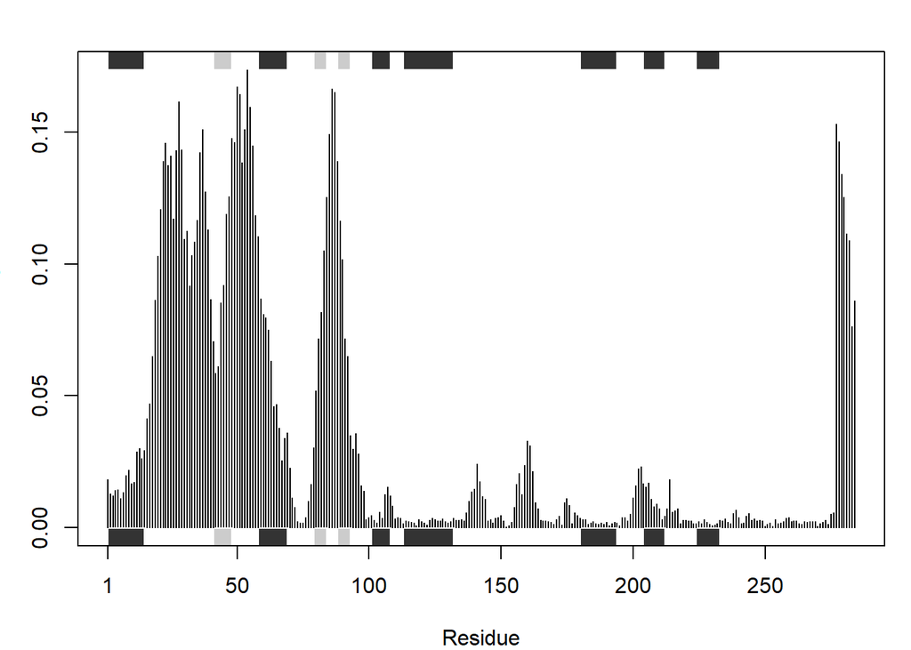

```r
plot.bio3d(pc$au[, 1], sse=pdbs2sse(pdbs), ylab="Loadings")
```

```r
#Saving a  trajectory showing the collective motion defined by PC1
mktrj(pc, pc=1, file="~/project/data/processed/pc_1.pdb")
```

## 4. Document and session details

These document represent the project from the Scientific Programming curse from Serrapilheira/ICTP-SAIFR Training Program in Quantitative Biology and Ecology

## 5. References

Berman, Helen M, John Westbrook, Zukang Feng, Gary Gilliland, Talapady N Bhat, Helge Weissig, Ilya N Shindyalov, and Philip E Bourne. 2000. “The Protein Data Bank.” *Nucleic Acids Research* 28 (1): 235–42.

Bodenhofer, Ulrich, Enrico Bonatesta, Christoph Horejš-Kainrath, and Sepp Hochreiter. 2015. “Msa: An r Package for Multiple Sequence Alignment.” *Bioinformatics* 31 (24): 3997–99.

Grant, Barry J, Ana PC Rodrigues, Karim M ElSawy, J Andrew McCammon, and Leo SD Caves. 2006. “Bio3d: An r Package for the Comparative Analysis of Protein Structures.” *Bioinformatics* 22 (21): 2695–96.

Grant, Barry J, Lars Skjærven, and Xin-Qiu Yao. 2021. “The Bio3D Packages for Structural Bioinformatics.” *Protein Science* 30 (1): 20–30.

Skjærven, Lars, Xin-Qiu Yao, Guido Scarabelli, and Barry J Grant. 2014. “Integrating Protein Structural Dynamics and Evolutionary Analysis with Bio3D.” *BMC Bioinformatics* 15 (1): 1–11.